# Cars in Qatar

Boglarka Ludmany

2026-05-18

`echo = TRUE` - the code chunks are visible

## Libraries

```r
library(tidyverse)
library(dplyr)
library(tidytuesdayR)
```

```r
library(readr)
library(stats)
library(ggplot2)
library(magrittr)
library(performance)
library(see)
library(patchwork)
library(lmtest)
```

# 1. Importing data - directly from GitHub

```r
qatarcars <- readr::read_csv("https://raw.githubusercontent.com/rfordatascience/tidytuesday/main/data/2025/2025-12-09/qatarcars.csv")
```

# Questions to explore from the tidytuesday GitHub repository

- What’s the distribution of price? (there are some really expensive cars here!)
- What’s the relationship between (logged) price and performance?
- Are there patterns across cars from different countries? Do some countries make more expensive cars? More electric cars?
- What’s the relationship between car dimensions and seating or trunk volume?

# 2. EDA

## 2.1. Exploring data structure, NA values

```r
view(qatarcars)
str(qatarcars) ## 105 rows altogether, data types are mainly double and character
```

```
## spc_tbl_ [105 × 15] (S3: spec_tbl_df/tbl_df/tbl/data.frame)
##  $ origin     : chr [1:105] "Germany" "Germany" "Germany" "Germany" ...
##  $ make       : chr [1:105] "BMW" "BMW" "Audi" "Audi" ...
##  $ model      : chr [1:105] "3 Series Sedan" "X1" "RS Q8" "RS3" ...
##  $ length     : num [1:105] 4.71 4.5 5.01 4.54 4.46 ...
##  $ width      : num [1:105] 1.83 1.84 1.69 1.85 1.96 ...
##  $ height     : num [1:105] 1.44 1.64 2 1.41 1.42 ...
##  $ seating    : num [1:105] 5 5 5 5 5 4 5 5 5 5 ...
##  $ trunk      : num [1:105] 59 505 605 321 425 500 480 610 435 565 ...
##  $ economy    : num [1:105] 7.6 6.6 12.1 8.7 6.5 13.3 13.1 NA 5.6 7.5 ...
##  $ horsepower : num [1:105] 386 313 600 400 180 612 585 333 163 221 ...
##  $ price      : num [1:105] 164257 264000 630000 310000 165000 ...
##  $ mass       : num [1:105] 1653 1701 2490 1565 1325 ...
##  $ performance: num [1:105] 4.3 5.4 3.6 3.8 6.7 4.1 4.3 5.6 6.8 9 ...
##  $ type       : chr [1:105] "Sedan" "SUV" "SUV" "Sedan" ...
##  $ enginetype : chr [1:105] "Petrol" "Petrol" "Petrol" "Petrol" ...
##  - attr(*, "spec")=
##   .. cols(
##   ..   origin = col_character(),
##   ..   make = col_character(),
##   ..   model = col_character(),
##   ..   length = col_double(),
##   ..   width = col_double(),
##   ..   height = col_double(),
##   ..   seating = col_double(),
##   ..   trunk = col_double(),
##   ..   economy = col_double(),
##   ..   horsepower = col_double(),
##   ..   price = col_double(),
##   ..   mass = col_double(),
##   ..   performance = col_double(),
##   ..   type = col_character(),
##   ..   enginetype = col_character()
##   .. )
##  - attr(*, "problems")=<externalptr>
```

```r
colSums(is.na(qatarcars)) ## NA values only in the economy variable
```

```
##      origin        make       model      length       width      height
##           0           0           0           0           0           0
##     seating       trunk     economy  horsepower       price        mass
##           0           0          10           0           0           0
## performance        type  enginetype
##           0           0           0
```

```r
economy_na <- qatarcars[!complete.cases(qatarcars),] ## investigating the reason behind NA values in the economy variable
economy_na ## electric cars cannot be evaluated by their fuel economy
```

```
## # A tibble: 10 × 15
##    origin      make   model length width height seating trunk economy horsepower
##    <chr>       <chr>  <chr>  <dbl> <dbl>  <dbl>   <dbl> <dbl>   <dbl>      <dbl>
##  1 Germany     Merce… EQS     5.22  1.93   1.51       5   610      NA        333
##  2 South Korea Hyund… Ioni…   4.64  1.89   1.60       5   527      NA        302
##  3 South Korea Kia    EV9     5.01  1.98   1.75       7   572      NA        215
##  4 UK          Jaguar I-Pa…   4.68  2.01   1.56       5   656      NA        395
##  5 UK          Lotus  Evija   4.46  2      1.12       2     0      NA       1973
##  6 USA         Tesla  Mode…   5.06  2.27   1.68       5  1233      NA        670
##  7 USA         Tesla  Mode…   4.75  1.92   1.62       5   480      NA        342
##  8 USA         Tesla  Mode…   4.72  1.85   1.44       5   542      NA        460
##  9 PR China    BYD    Seal    4.8   1.88   1.46       5   400      NA        204
## 10 PR China    BYD    Atto…   4.46  1.88   1.62       5   440      NA        201
## # ℹ 5 more variables: price <dbl>, mass <dbl>, performance <dbl>, type <chr>,
## #   enginetype <chr>
```

Value ranges with `summary`

```r
summary(qatarcars)
```

```
##     origin              make              model               length
##  Length:105         Length:105         Length:105         Min.   :3.595
##  Class :character   Class :character   Class :character   1st Qu.:4.495
##  Mode  :character   Mode  :character   Mode  :character   Median :4.681
##                                                           Mean   :4.664
##                                                           3rd Qu.:4.850
##                                                           Max.   :5.469
##
##      width           height         seating         trunk
##  Min.   :1.595   Min.   :1.122   Min.   :2.00   Min.   :   0.0
##  1st Qu.:1.818   1st Qu.:1.455   1st Qu.:5.00   1st Qu.: 284.0
##  Median :1.875   Median :1.540   Median :5.00   Median : 448.0
##  Mean   :1.914   Mean   :1.574   Mean   :5.01   Mean   : 437.6
##  3rd Qu.:1.979   3rd Qu.:1.685   3rd Qu.:5.00   3rd Qu.: 542.0
##  Max.   :4.633   Max.   :1.998   Max.   :8.00   Max.   :1233.0
##
##     economy         horsepower         price               mass
##  Min.   : 1.200   Min.   :  76.0   Min.   :   35000   Min.   : 945
##  1st Qu.: 6.500   1st Qu.: 154.0   1st Qu.:   91000   1st Qu.:1428
##  Median : 7.600   Median : 248.0   Median :  164000   Median :1701
##  Mean   : 8.698   Mean   : 317.8   Mean   :  796573   Mean   :1776
##  3rd Qu.:10.650   3rd Qu.: 380.0   3rd Qu.:  310000   3rd Qu.:2055
##  Max.   :22.500   Max.   :1973.0   Max.   :33000000   Max.   :2746
##  NA's   :10
##   performance         type            enginetype
##  Min.   : 2.400   Length:105         Length:105
##  1st Qu.: 4.800   Class :character   Class :character
##  Median : 6.900   Mode  :character   Mode  :character
##  Mean   : 7.101
##  3rd Qu.: 8.800
##  Max.   :14.500
##
```

Unique values of `origin` and `make`

```r
origin_values <- tibble(unique(qatarcars$origin))
origin_values
```

```
## # A tibble: 8 × 1
##   `unique(qatarcars$origin)`
##   <chr>
## 1 Germany
## 2 Italy
## 3 Japan
## 4 PR China
## 5 South Korea
## 6 Sweden
## 7 UK
## 8 USA
```

```r
brand_values <- tibble(unique(qatarcars$make))
brand_values
```

```
## # A tibble: 31 × 1
##    `unique(qatarcars$make)`
##    <chr>
##  1 BMW
##  2 Audi
##  3 Mercedes
##  4 Porsche
##  5 Volkswagen
##  6 Bugatti
##  7 Maserati
##  8 Toyota
##  9 Honda
## 10 Lexus
## # ℹ 21 more rows
```

## 2.2. Visualizations, Distributions

### A. Univariate distributions

#### Horsepower

```r
range(qatarcars$horsepower)
```

```
## [1]   76 1973
```

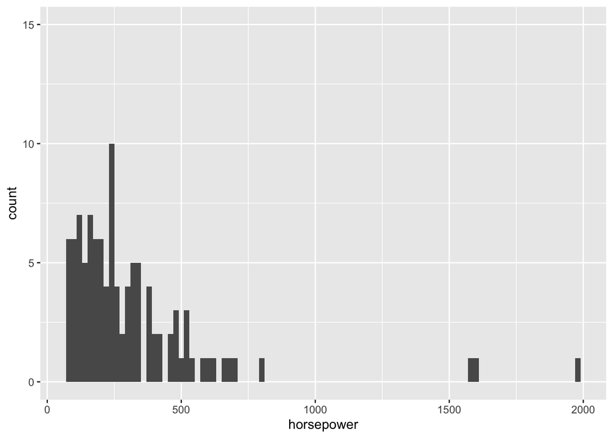

```r
horsepower_plot <- ggplot(qatarcars, aes(x = horsepower)) +
  geom_histogram(binwidth = 20) +
  scale_y_continuous(limits = c(0, 15),
                   breaks = waiver())

horsepower_plot
```

The distribution of horsepower is right-skewed: most cars are concentrated in the lower range, while a few high-performance outliers can also be observed.

#### Type of the car (`type`)

```r
unique(qatarcars$type)
```

```
## [1] "Sedan"     "SUV"       "Coupe"     "Hatchback"
```

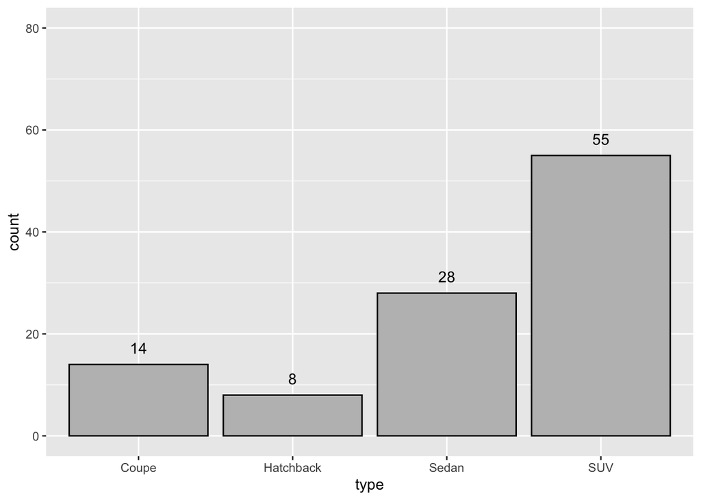

```r
ggplot(qatarcars, aes(x = type)) +
  geom_histogram(stat = "count",
                 color = "black",
                 fill = "grey") +
  scale_y_continuous(limits = c(0, 80)) +
  geom_text(
    stat = "count",
    aes(label = after_stat(count)),
    vjust = -1
  )
```

```r
## extracting the distribution of the types of cars from the original dataset
type_sum <- qatarcars %>%
  count(type, name = "count")
```

#### Type of the engine (`enginetype`)

```r
unique(qatarcars$enginetype)
```

```
## [1] "Petrol"   "Electric" "Hybrid"
```

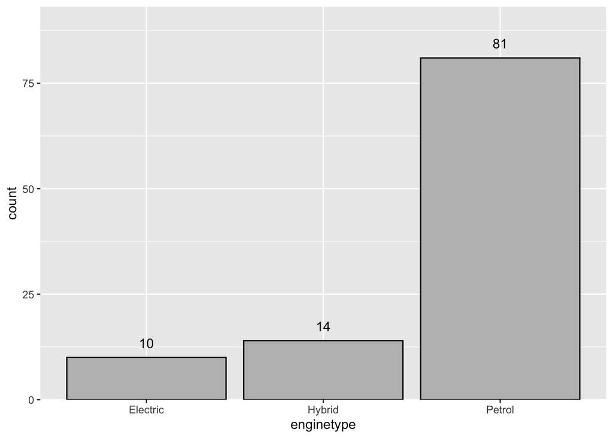

```r
enginetype_counts <- qatarcars %>%
  count(enginetype, name = "count") %>%
  mutate(percent = round(count / sum(count) * 100, 1))

ggplot(enginetype_counts, aes(x = enginetype, y = count)) +
  geom_bar(stat = "identity", color = "black", fill = "grey") +
  scale_y_continuous(expand = expansion(mult = c(0, 0.15))) +
  geom_text(
    aes(label = count),
    vjust = -1
  )
```

Majority of the cars are fueled by petrol (77.1%), hybrid (13.3%) and electric cars (9.5%) are present in smaller extent.

#### Origin (`origin`)

```r
unique(qatarcars$origin)
```

```
## [1] "Germany"     "Italy"       "Japan"       "PR China"    "South Korea"
## [6] "Sweden"      "UK"          "USA"
```

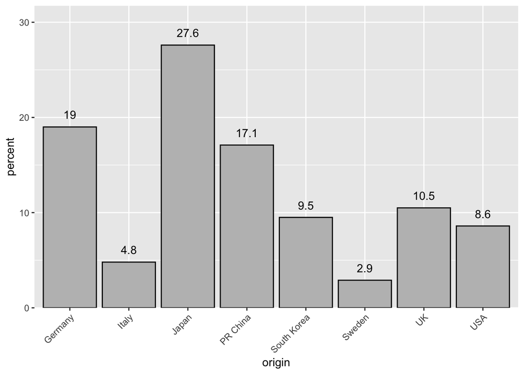

```r
origin_counts <- qatarcars %>%
  count(origin, name = "count") %>%
  mutate(percent = round(count / sum(count) * 100, 1))

## this plot visualizes the percentages of each country of origin
ggplot(origin_counts, aes(x = origin, y = percent)) +
  geom_bar(stat = "identity", color = "black", fill = "grey") +
  scale_y_continuous(expand = expansion(mult = c(0, 0.15))) +
  geom_text(
    aes(label = percent),
    vjust = -1
  ) +
  theme(axis.text.x = element_text(angle = 45, hjust = 1))
```

The majority of the cars originated from Japan (27.6%), followed by Germany (19%) and China (17.1%). A smaller proportion comes from the UK (10.5%), South Korea (9.5%), the USA (8.6%), Italy (4.8%), and Sweden (2.9%).

#### Car brands

```r
qatarcars %>% summarise(n_brands = n_distinct(make))
```

```
## # A tibble: 1 × 1
##   n_brands
##      <int>
## 1       31
```

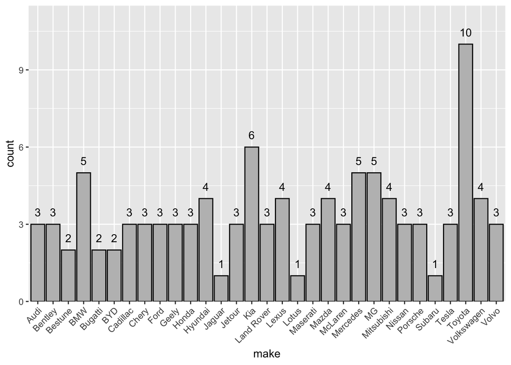

```r
brands_counts <- qatarcars %>%
  count(make, name = "count") %>%
  mutate(percent = round(count / sum(count) * 100, 1))

ggplot(brands_counts, aes(x = make, y = count)) +
  geom_bar(stat = "identity", color = "black", fill = "grey") +
  scale_y_continuous(expand = expansion(mult = c(0, 0.15))) +
  geom_text(
    aes(label = count),
    vjust = -1
  ) +
  theme(axis.text.x = element_text(angle = 45, hjust = 1))
```

The dataset includes 31 distinct car brands, with Toyota being the most represented (*n* = 10), followed by Kia (*n* = 6), BMW (*n* = 5), Mercedes (*n* = 5), and MG (*n* = 5). The majority of the brands appear only 3-4 times, three brands (Jaguar, Lotus, and Subaru) have only one observation. This distribution can be interpreted as highly uneven, indicating that brand-level comparisons should be interpreted with caution.

### B. Multivariate Distributions

To explore the relationship between engine performance and fuel consumption, a scatterplot of horsepower versus fuel consumption (L/100 km), by engine type is presented.

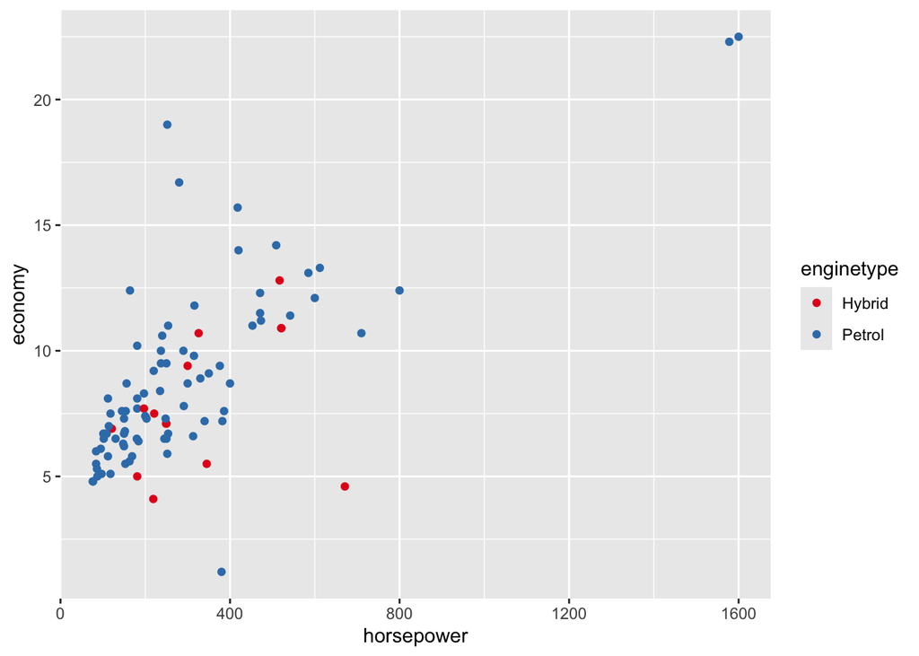

```r
economy_data <- qatarcars %>%
  filter(enginetype != "Electric") %>% ## fuel economy cannot be interpreted in the case of electric cars
  select(enginetype, horsepower, economy)

economy_horsepower_plot <- ggplot(economy_data, aes(x = horsepower, y = economy, fill = enginetype)) +
  geom_point(aes(colour = enginetype)) +
  scale_color_brewer(palette = "Set1")

economy_horsepower_plot
```

This plot suggests a not clearly linear, but positive trend between horsepower and fuel consumption (indicating that more powerful cars tend to be less fuel-efficient). The relationship suggests an increasing variability at higher horsepower levels.

To further explore the differences in fuel consumption between engine types, a boxplot was created.

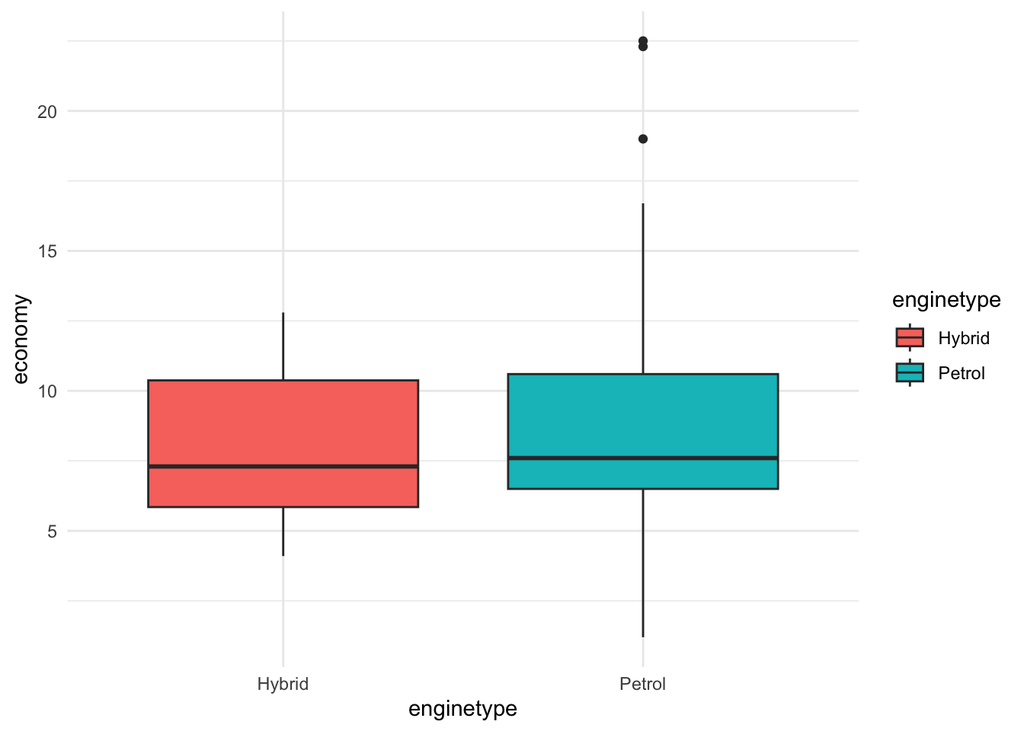

```r
no_electric <- qatarcars %>%
  filter(enginetype != "Electric")

enginetype_economy_plot <- ggplot(no_electric, aes(x = enginetype, y = economy, fill = enginetype)) +
  geom_boxplot() +
  theme_minimal()

enginetype_economy_plot
```

Petrol vehicles greater variabiliy in fuel consumption, while there is only a slight difference in the medians of the consumption of hybrid and petrol.

In order to further explore the different characteristics of the engine types, a scatterplot of horsepower and performance, by engine type was created.

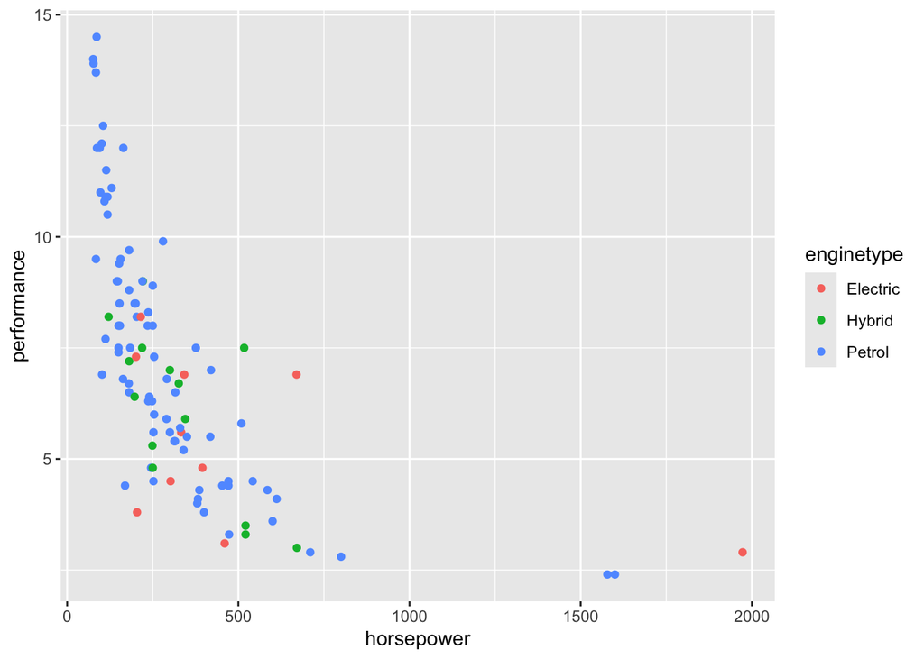

```r
ggplot(qatarcars, aes(x = horsepower, y = performance, fill = enginetype)) +
  geom_point(aes(colour = enginetype))
```

This plot suggests a negative relationship between horsepower and performance, indicating that vehicles with higher horsepower tend to have lower performance values. The relationship is nonlinear: performance decreases rapidly, as horsepower increases. This pattern is explicitly strong in the cases of cars fueled by petrol.

Horsepower and mass

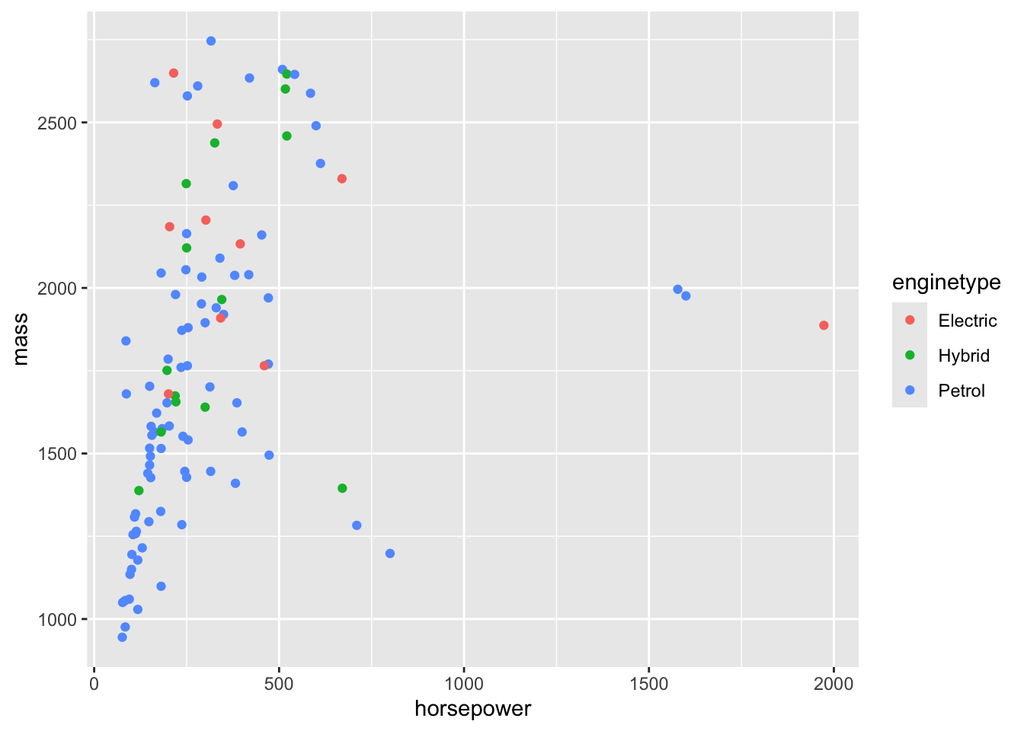

```r
ggplot(qatarcars, aes(x = horsepower, y = mass, fill = enginetype)) +
  geom_point(aes(color = enginetype))
```

This scatterplot indicates a positive relationship between horsepower and vehicle mass, suggesting that more powerful cars tend to be heavier.

To examine how vehicle horsepower differs by country of origin, a boxplot of horsepower across origins is presented.

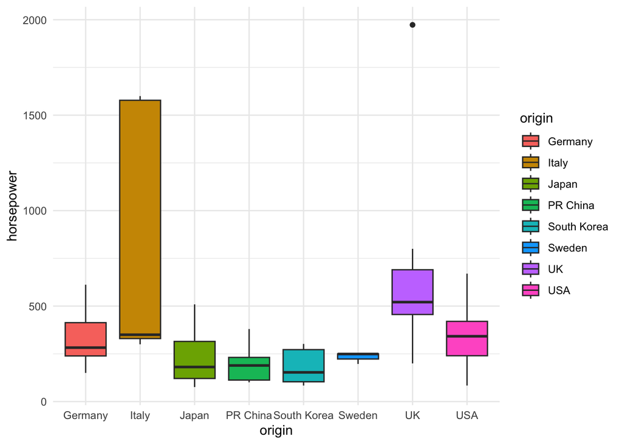

```r
origin_horsepower <- qatarcars %>%
  select(horsepower, origin)

ggplot(origin_horsepower, aes(x = origin, y = horsepower, fill = origin)) +
  geom_boxplot() +
  theme_minimal()
```

Vehicles from the UK and Italy tend to have higher horsepower values; Italian cars show the greatest variability in horsepower, suggesting the presence of many high-performance vehicles.

# 3. Hypotheses

Based on the exploratory data analysis and visualizations, the following hypotheses were formed: H1: Higher horsepower can be associated with higher fuel consumption, controlling for engine type.

More powerful cars may consume more fuel, however, it needs to be taken into account that fuel consumption may also vary across different engine types, therefore, engine type needs to be added to the hypothesis as a control variable. Therefore, our question regarding this hypothesis becomes: If two cars have the same engine type, does higher horsepower increase fuel consumption?

# 4. Statistical Modelling

H1: Higher horsepower can be associated with higher fuel consumption, controlling for engine type.

To test this hypothesis, a linear regression model was used, with `ecnonomy` as the outcome variable, and `horsepower` and `enginetype` as predictors. Horsepower is the primary explanatory variable, engine type is added as a control variable to account for differences between vehicles. Electric cars were not included in the analysis, since electric cars do not consume fuel (therefore, in the case of cars with said engine type, the variable `economy` had NA values). The assumptions of the linear regression (linearity, independence of observations, homoskedasticity, normality of residuals, and no multicollinearity) were assessed using standard diagnostic measures.

## 4.1. Assumptions before fitting the model:

The following assumptions were assessed before fitting the model: - Linearity - No multicollinearity - Outliers - Sufficient sample size

Assumptions that were checked after fitting the model (on model residuals): - Normality of residuals - Homoscedasticity - Independence of residuals - Linearity (in residuals) - No influential outliers - Multicollinearity (VIF)

#### Linearity

According to the linearity assumption, the relationship between the dependent variable and independent variable should be linear. Stated differently, changes in the independent variable should result in constant changes in the dependent variable. The following scatterplot (as created before) is sufficient.

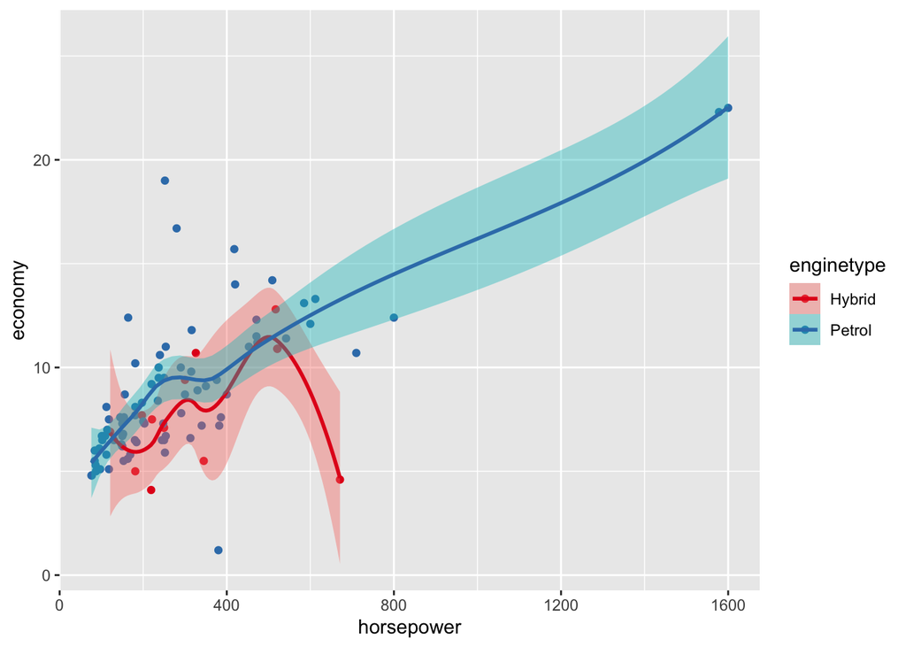

```r
ggplot(economy_data, aes(x = horsepower, y = economy, fill = enginetype)) +
  geom_point(aes(colour = enginetype)) +
  scale_color_brewer(palette = "Set1") +
  geom_smooth(method = "loess", se = TRUE, aes(color = enginetype))
```

On the scatterplot, a loess smoothing curve was added to assess the linearity based on the control variable. The data is heavily clustered around the 0-400 horsepower range, with very few observations at higher values; therefore, this relationship is harder to assess reliabily within the full range. There are potential outliers. For petrol vehicles, the relationship appeared to be broadly positive, although the curve is influenced by outliers at ~1600 hp. For hybrid vehicles, the curve shows a non-linear pattern (likely due to the small number of observations). Overall, the linearity assumption was considered violated, therefore, as a potential solution to this problem, `horsepower` was log-transformed.

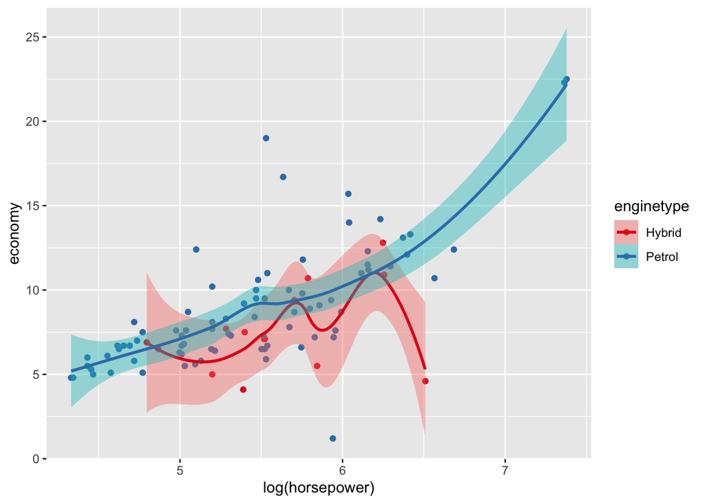

```r
ggplot(economy_data, aes(x = log(horsepower), y = economy, fill = enginetype)) +
  geom_point(aes(colour = enginetype)) +
  scale_color_brewer(palette = "Set1") +
  geom_smooth(method = "loess", se = TRUE, aes(color = enginetype))
```

As can be seen on this plot, the log-transformation of horsepower did not improve the linearity of the relationship. Since the number of hybrid observations are rather small, and a high-leverage outlier is present, the linearity assumption was assessed primarily trough post-fit residual diagnostics.

##### Multicollinearity

To assess potential multicollinearity between the predictors (continuous: `horsepower` and categorical: `enginetype`), the distribution of horsepower was examined for hybrid and petrol vehicles, using a boxplot. (As stated before, electric vehicles were excluded from the analysis, as fuel economy cannot be analyised in the case of fully electric cars.) The distribution of horsepower was similar, with a substantial overlap, suggesting that multicollinearity between the predictors is unlikely to be concerning.  
Multicollinearity was further assessed using Variance Inflation Factors following model fitting.

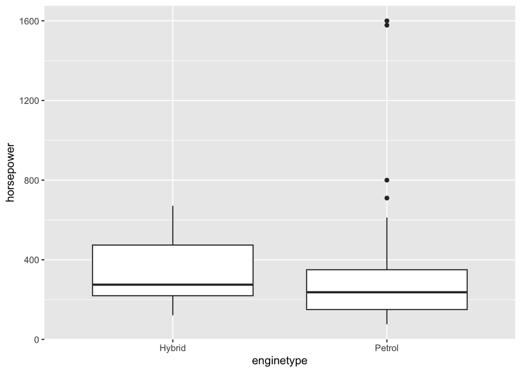

```r
ggplot(no_electric, aes(x = enginetype, y = horsepower)) +
  geom_boxplot()
```

Assumptions that were checked after fitting the model (on model residuals): - Normality of residuals - Homoscedasticity - Independence of residuals - Linearity (in residuals) - No influential outliers - Multicollinearity (VIF)

The final sample size is 95 vehicles (not including the electric cars).

```r
nrow(no_electric)
```

```
## [1] 95
```

# 4.2. Model fitting

To test the hypothesis (Higher horsepower is associated with greater fuel consumption, after controlling for engine type.), a linear regression model was fitted on the data, with economy as the outcome variable, and horsepower and engine type as predictors. As stated before, electric vehicles were excluded from the analysis `(n = 10)`, as fuel economy cannot be interpreted in the case of electric cars.

```r
model <- lm(economy ~ horsepower + enginetype, data = no_electric)
summary(model)
```

```
##
## Call:
## lm(formula = economy ~ horsepower + enginetype, data = no_electric)
##
## Residuals:
##     Min      1Q  Median      3Q     Max
## -8.5740 -1.2932 -0.1654  1.0867 10.5798
##
## Coefficients:
##                  Estimate Std. Error t value Pr(>|t|)
## (Intercept)      4.366843   0.736486   5.929 5.26e-08 ***
## horsepower       0.010576   0.001021  10.363  < 2e-16 ***
## enginetypePetrol 1.388052   0.709695   1.956   0.0535 .
## ---
## Signif. codes:  0 '***' 0.001 '**' 0.01 '*' 0.05 '.' 0.1 ' ' 1
##
## Residual standard error: 2.448 on 92 degrees of freedom
## Multiple R-squared:  0.5429, Adjusted R-squared:  0.533
## F-statistic: 54.63 on 2 and 92 DF,  p-value: 2.294e-16
```

Before interpreting the regression results, the following assumptions of the model residuals were checked: - Normality of residuals, - Homoscedasticity, - Independence of residuals, - Linearity (in residuals), - Multicollinearity (VIF). The assessment of the assumptions was executed using the `performance` package (Lüdecke et al., 2021).

#### Normality of residuals

Normality of residuals was first assessed using the Shapiro-Wilk test (`performance::check_normality()`). Results indicated that the distribution of the residuals significantly deviated from the normal distribution (*W* = 0.88235, *p* < .001).

```r
performance::check_normality(model)
shapiro.test(residuals(model))
```

```
##
##  Shapiro-Wilk normality test
##
## data:  residuals(model)
## W = 0.88235, p-value = 4.01e-07
```

A density plot was used to visually investigate the distribution of the residuals. The density plot indicated a right-skewed distribution, as the residuals did not closely follow the theoretical normal curve.

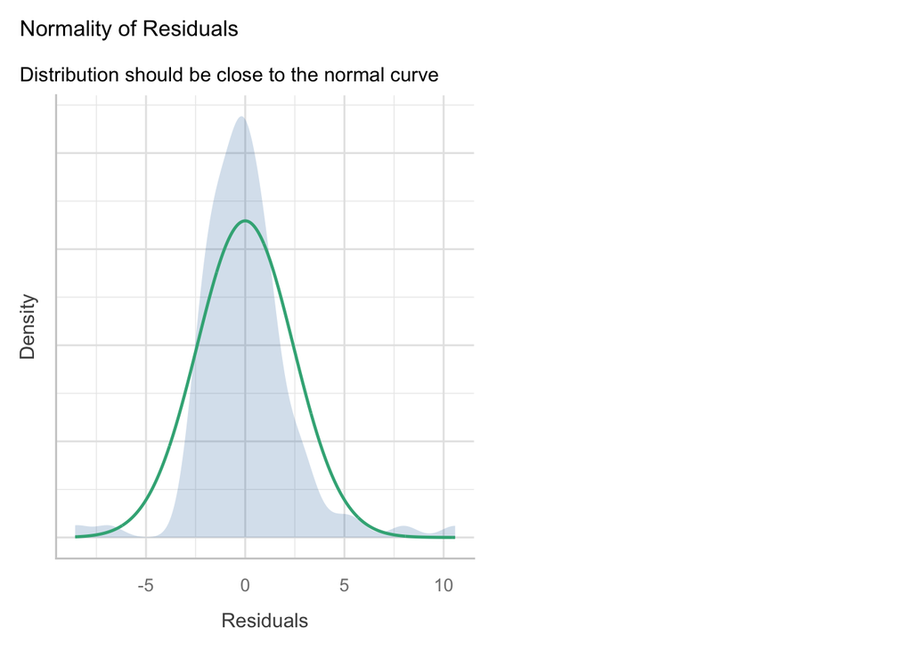

```r
performance::check_model(model, check = "normality")
```

Visual inspection of the Q-Q plot revealed that the residuals deviated from the reference line (particularly, at the tails), suggesting a violation of normality.

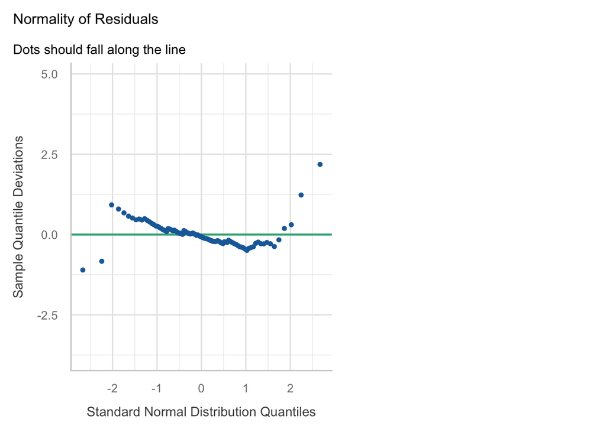

```r
performance::check_model(model, check = "qq")
```

In order to assess the violation of the normality assumption, a log transformation of the outcome variable (`economy`) was explored. However, the normality assumption remained violated following the transformation. Therefore, the untransformed model was retained, and the violation is acknowledged as a limitation. According to the central limit theorem, the sampling distribution of regression coefficients approximates normality at this sample size (*n* = 95); this reduces the impact of the violation of the normality assumption.

```r
model2 <- lm(log(economy) ~ horsepower + enginetype, data = no_electric)
shapiro.test(residuals(model2))
```

```
##
##  Shapiro-Wilk normality test
##
## data:  residuals(model2)
## W = 0.82578, p-value = 3.251e-09
```

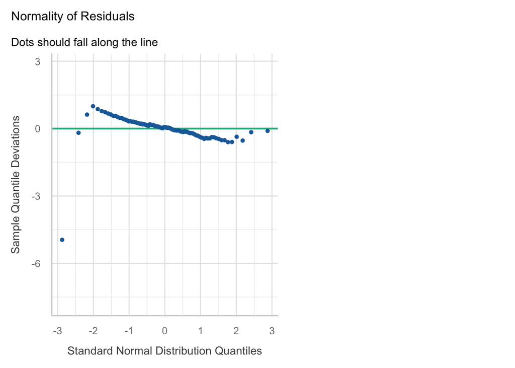

```r
performance::check_model(model2, check = "qq")
```

#### Homoscedasticity

```r
performance::check_heteroskedasticity(model, check = "homogenity")
```

```
## OK: Error variance appears to be homoscedastic (p = 0.313).
```

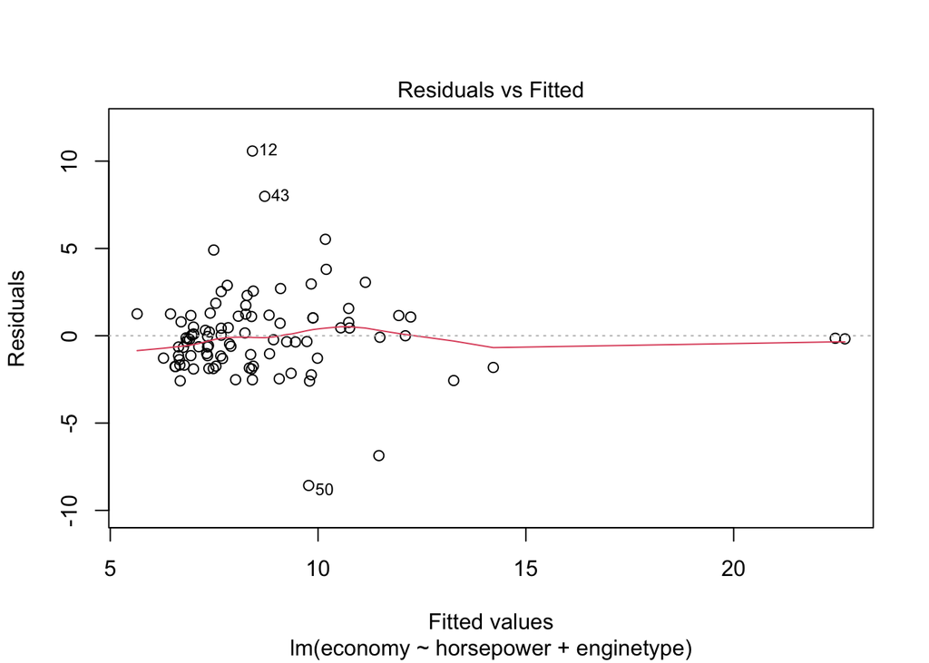

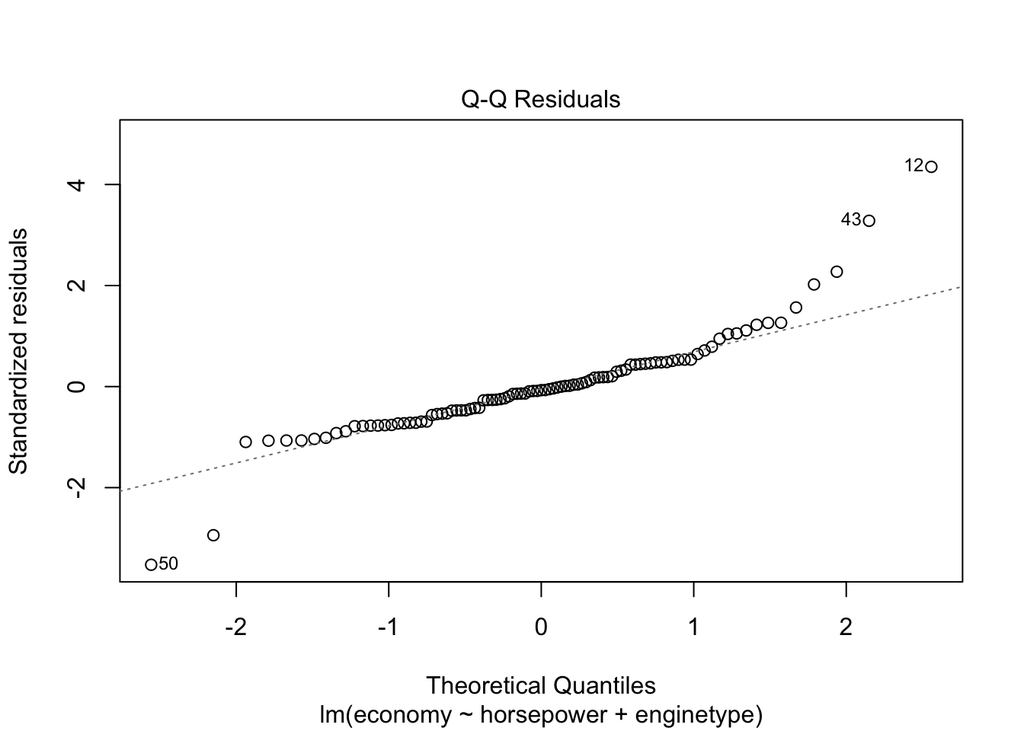

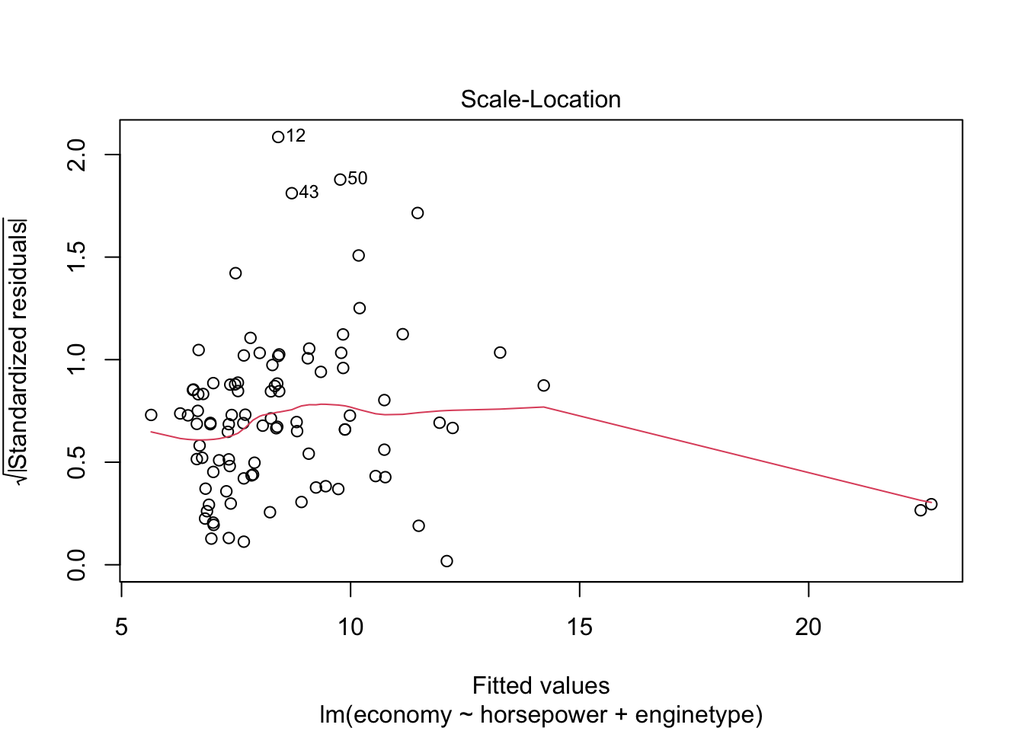

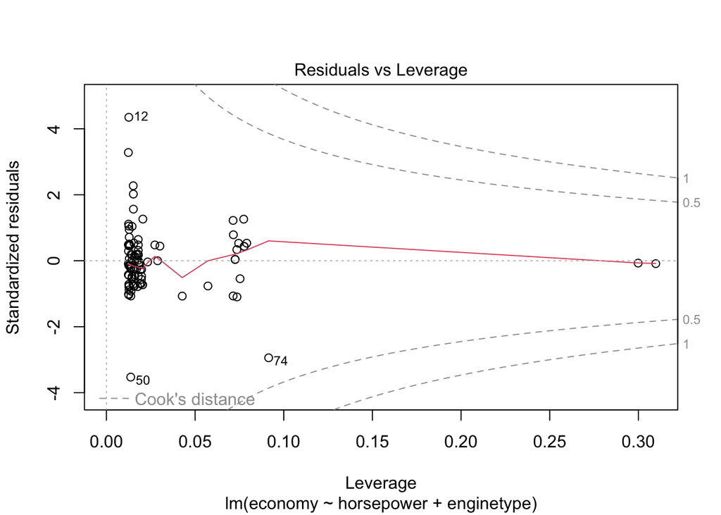

```r
plot(model)
```

#### Independence of residuals

```r
performance::check_autocorrelation(model)
```

```
## OK: Residuals appear to be independent and not autocorrelated (p = 0.162).
```

#### Linearity of residuals

Linearity of residuals was assessed visually using the Residuals vs Fitted plot, and formally using the Rainbow test. The visual inspection indicated a slight curvature in the reference line; the deviance from was minor. The Rainbow test indicated no significant violation of linearity (*Rain* = 1.1174, *df1* = 48, *df2* = 44, *p* = .356).

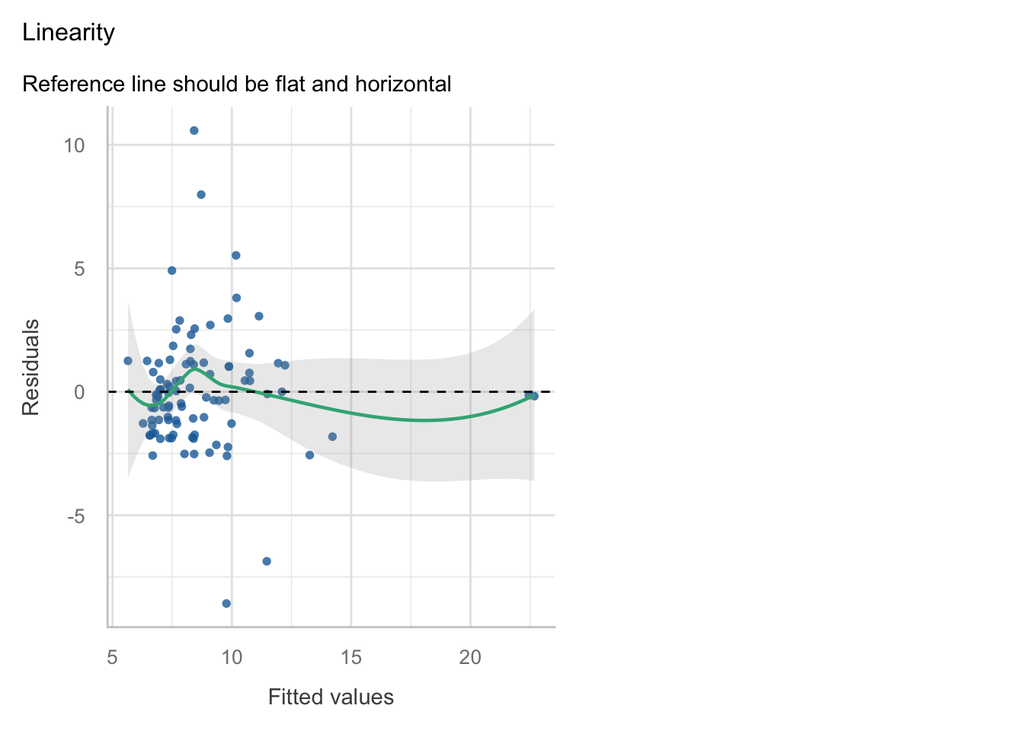

```r
performance::check_model(model, check = "linearity")
```

```r
lmtest::raintest(model)
```

```
##
##  Rainbow test
##
## data:  model
## Rain = 1.1174, df1 = 48, df2 = 44, p-value = 0.3559
```

#### Multicollinearity (Variance Inflation Factor - VIF)

Multicollinearity was assessed visually using a VIF plot, and formally using the `performance::check_collinearity()` function. Both predictors yielded a VIF value of 1.00, indicating that no multicollinearity was present between horsepower and engine type.

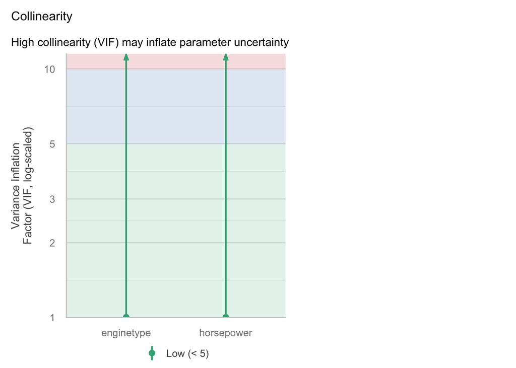

```r
performance::check_model(model, check = "vif")
```

```r
performance::check_collinearity(model)
```

```
## # Check for Multicollinearity
##
## Low Correlation
##
##        Term  VIF  VIF 95% CI adj. VIF Tolerance Tolerance 95% CI
##  horsepower 1.00 [1.00, Inf]     1.00      1.00     [0.00, 1.00]
##  enginetype 1.00 [1.00, Inf]     1.00      1.00     [0.00, 1.00]
```

#### Outlier diagnostics

Potential outliers were assessed using Cook’s distance measures (`performance::check_model()`). The assessment revealed that all observations fell within the acceptable boundaries, no influential outliers were detected (threshold: Cook’s D > 0.70).

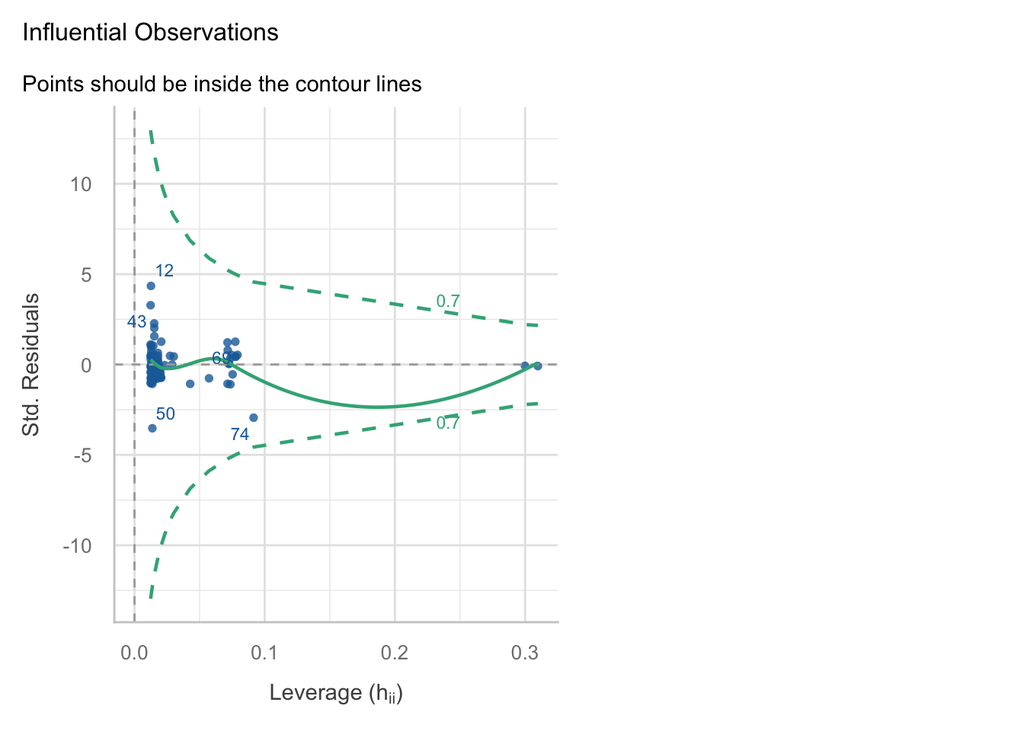

```r
performance::check_model(model, check = "outliers")
```

```r
performance::check_outliers(model)
```

```
## OK: No outliers detected.
## - Based on the following method and threshold: cook (0.7).
## - For variable: (Whole model)
```

# 5. Diagnostics

```r
summary(model)
```

```
##
## Call:
## lm(formula = economy ~ horsepower + enginetype, data = no_electric)
##
## Residuals:
##     Min      1Q  Median      3Q     Max
## -8.5740 -1.2932 -0.1654  1.0867 10.5798
##
## Coefficients:
##                  Estimate Std. Error t value Pr(>|t|)
## (Intercept)      4.366843   0.736486   5.929 5.26e-08 ***
## horsepower       0.010576   0.001021  10.363  < 2e-16 ***
## enginetypePetrol 1.388052   0.709695   1.956   0.0535 .
## ---
## Signif. codes:  0 '***' 0.001 '**' 0.01 '*' 0.05 '.' 0.1 ' ' 1
##
## Residual standard error: 2.448 on 92 degrees of freedom
## Multiple R-squared:  0.5429, Adjusted R-squared:  0.533
## F-statistic: 54.63 on 2 and 92 DF,  p-value: 2.294e-16
```

The model explained 53.3% of the variance in the data (*R^2* = .5429, *adjusted R^2* = .533, *F(2,92)* = 54.63, *p* < .001). `horsepower` was a significant positive predictor of `economy` (*b* = 0.011, *SE* = 0.001, *t(92)* = 10.363, *p* < .001), suggesting that higher horsepower was associated with greater fuel consumption, controlling for engine type. No significant effect of engine type was found (*b* = 1.388, *SE* = 0.71, *t(92)* = 1.956, *p* = .054).

# 6. Conclusions

The aim of the present analysis was to explore whether higher horsepower is associated with greater consumption of fuel (`economy`), controlling for engine type. The sample size consisted of 95 non-electric vehicles. A linear regression model was fitted with `economy` as the outcome variable, and `horsepower` and `enginetype` as predictors. The model results and diagnostics suggested that the predictors together account for a substantial portion of the variability in fuel consumption (*R^2* = .543, *adjusted R^2* = .533, *F(2, 92)* = 54.63, *p* < .001). The hypothesis was supported: horsepower was a significant positive predictor of fuel economy (*b* = 0.011, *SE* = 0.001, *t(92)* = 10.363, *p* < .001), however, no significant effect of engine type was found (*b* = 1.388, *SE* = 0.71, *t(92)* = 1.956, *p* = .054). Certain limitations should be noted. The assumption of normality was violated (*W* = 0.88235, *p* < .001), and the log-transformation of the outcome variable did not seem to resolve this violation. The data were heavily concentrated at lower horsepower values, with very few vehicles at higher ranges, therefore, the reliability of the model across the full range is rather questionable. The small number of hybrid vehicles further limits the generalisability of the analysis.